# HTML_code_Chest_ray

### Transfer learning for Multiple classes and Multiple labels

In this notebook, Chest X-Ray dataset has 112120 gray scale images with 1024 by 1024 image size. The dataset contains x-ray images that shows one or more Thorax Disease and the total number of diseases is 14. This make the problem as multiple class and multiple labels problem. The volume of this dataset is around 43GB. In this example, transfer learning is used by training the model from scratch without freezing any layers. The first step is reading images from HDFS and then convert all images into SQL spark dataframe. You can refer to the convert images notebook which reads all images from HDFS and convert them into SQL spark dataframe. The code also assigned with labels for each image by reading CVS file that contains image indexes and their labels.

## Vistualize the statistical Information about dataset

The dataset statistical information can be visualized in our dataset statistical data code.

## Import the required packages

In this following cell all required packages are downloaded. If you got any error try to install the required package using pip command or download the required library such as BigDL.

```python
import random
import time
from math import ceil
from bigdl.optim.optimizer import SGD, SequentialSchedule, Warmup, Poly, Plateau, EveryEpoch, TrainSummary,\
    ValidationSummary, SeveralIteration, Step, L2Regularizer
from pyspark.ml.evaluation import BinaryClassificationEvaluator
from pyspark.sql import SparkSession, SQLContext
from pyspark.sql.functions import col, udf
from pyspark.sql.types import DoubleType
from pyspark.storagelevel import StorageLevel
from zoo.common.nncontext import *
from zoo.feature.image.imagePreprocessing import *
from zoo.feature.common import ChainedPreprocessing
from zoo.pipeline.api.keras.layers import Input, Flatten, Dense, GlobalAveragePooling2D, Dropout
from zoo.pipeline.api.keras.metrics import AUC
from zoo.pipeline.api.keras.optimizers import Adam
from zoo.pipeline.api.keras.models import Model
from zoo.pipeline.api.net import Net
from zoo.pipeline.nnframes import NNEstimator
from zoo.pipeline.api.keras.objectives import BinaryCrossEntropy
```

## Inception pre-trained model

After downloading the pre-trained models and moving them to HDFS, now you can upload and use any of them as shown in the following cells

```python
def get_inception_model(model_path, label_length):
    full_model = Net.load_bigdl(model_path)
    model = full_model.new_graph(["pool5/drop_7x7_s1"])  # this inception
    inputNode = Input(name="input", shape=(3, 224, 224))
    inception = model.to_keras()(inputNode)
    flatten = GlobalAveragePooling2D(dim_ordering='th')(inception)
    dropout = Dropout(0.25)(flatten)
    logits = Dense(label_length, W_regularizer=L2Regularizer(1e-1), b_regularizer=L2Regularizer(1e-1), activation="sigmoid")(dropout)
    lrModel = Model(inputNode, logits)
    return lrModel
```

```python
def get_resnet_model(model_path, label_length):
    full_model = Net.load_bigdl(model_path)
    model = full_model.new_graph(["pool5"])
    print(('num of model layers: ', len(model.layers)))
    inputNode = Input(name="input", shape=(3, 224, 224))
    resnet = model.to_keras()(inputNode)
    flatten = GlobalAveragePooling2D(dim_ordering='th')(resnet)
    dropout = Dropout(0.2)(flatten)
    logits = Dense(label_length, W_regularizer=L2Regularizer(1e-1), b_regularizer=L2Regularizer(1e-1), activation="sigmoid")(dropout)
    lrModel = Model(inputNode, logits)
    return lrModel
```

```python
def get_vgg_model(model_path, label_length):
    full_model = Net.load_bigdl(model_path)
    model = full_model.new_graph(["pool5"])
    print(('num of model layers: ', len(model.layers)))
    inputNode = Input(name="input", shape=(3, 224, 224))
    vgg_16 = model.to_keras()(inputNode)
    flatten = GlobalAveragePooling2D(dim_ordering='th')(vgg_16)
    dropout = Dropout(0.25)(flatten)
    logits = Dense(label_length, W_regularizer=L2Regularizer(1e-1), b_regularizer=L2Regularizer(1e-1), activation="sigmoid")(dropout)
    lrModel = Model(inputNode, logits)
    return lrModel
```

```python
def get_densenet_model(model_path, label_length):
    full_model = Net.load_bigdl(model_path)
    model = full_model.new_graph(["pool5"])
    print(('num of model layers: ', len(model.layers)))
    inputNode = Input(name="input", shape=(3, 224, 224))
    densenet = model.to_keras()(inputNode)
    flatten = GlobalAveragePooling2D(dim_ordering='th')(densenet)
    dropout = Dropout(0.25)(flatten)
    logits = Dense(label_length, W_regularizer=L2Regularizer(1e-1), b_regularizer=L2Regularizer(1e-1), activation="sigmoid")(dropout)
    lrModel = Model(inputNode, logits)
    return lrModel
```

## Learning Rate Scheduler for SGD optimizer

```python
def get_sgd_optimMethod(num_epoch, trainingCount, batchSize):
    iterationPerEpoch = int(ceil(float(trainingCount) / batchSize))
    # maxIteration = num_epoch * iterationPerEpoch
    warmupEpoch = 10
    warmup_iteration = warmupEpoch * iterationPerEpoch
    init_lr = 1e-6
    maxlr = 0.001 * batch_size / 8
    print("peak lr is: ", maxlr)
    warmupDelta = (maxlr - init_lr) / warmup_iteration
    cooldownIteration = (num_epoch - warmupEpoch) * iterationPerEpoch

    lrSchedule = SequentialSchedule(iterationPerEpoch)
    lrSchedule.add(Warmup(warmupDelta), warmup_iteration)
    #lrSchedule.add(Step(iterationPerEpoch * 10, 0.1), cooldownIteration)
    lrSchedule.add(Plateau("Loss", factor=0.1, patience=1, mode="min", epsilon=0.01, cooldown=0, min_lr=1e-15 ), cooldownIteration)
    optim = SGD(learningrate=init_lr, momentum=0.9, dampening=0.0, nesterov=True,
                leaningrate_schedule=lrSchedule)
    return optim
```

## Learning Rate Scheduler for ADAM optimizer

```python
def get_adam_optimMethod(num_epoch, trainingCount, batchSize):
    iterationPerEpoch = int(ceil(float(trainingCount) / batchSize))
    warmupEpoch = 5
    warmup_iteration = warmupEpoch * iterationPerEpoch
    init_lr = 0.0001 #1e-7
    maxlr = 0.001
    print("peak lr is: ", maxlr)
    warmupDelta = (maxlr - init_lr) / warmup_iteration
    cooldownIteration = (num_epoch - warmupEpoch) * iterationPerEpoch

    lrSchedule = SequentialSchedule(iterationPerEpoch)
    lrSchedule.add(Warmup(warmupDelta), warmup_iteration)
    lrSchedule.add(Plateau("Loss", factor=0.1, patience=1, mode="min", epsilon=0.01, cooldown=0, min_lr=1e-15 ),
                   cooldownIteration)
    optim = Adam(lr=init_lr, schedule=lrSchedule)
    return optim
```

```python
def get_auc_for_kth_class(k, df, label_col="label", prediction_col="prediction"):
    get_Kth = udf(lambda a: a[k], DoubleType())
    extracted_df = df.withColumn("kth_label", get_Kth(col(label_col))) \
        .withColumn("kth_prediction", get_Kth(col(prediction_col))) \
        .select('kth_label', 'kth_prediction')
    # areaUnderROC|areaUnderPR
    roc_score = BinaryClassificationEvaluator(rawPredictionCol='kth_prediction',
                                              labelCol='kth_label',
                                              metricName="areaUnderROC") \
        .evaluate(extracted_df)

    return roc_score
```

## Plot AUC

This evaluate and printout auc for all 14 classes

```python
%matplotlib notebook
%pylab inline
def plotingAuc(roc_auc_label):
    print ("plot of Area Under Curve for 14 classes ")
    lists=[]
    lists = sorted(roc_auc_label.items())
    label_texts = ["Atelectasis", "Cardiomegaly", "Effusion", "Infiltration", "Mass", "Nodule", "Pneumonia",
                   "Pneumothorax", "Consolidation","Edema", "Emphysema", "Fibrosis", "Pleural_Thickening", "Hernia"]
    x, y =zip(*lists)
    label_map = {k: v for v, k in enumerate(label_texts)}
    import numpy as np
    rng = np.random.RandomState(0)
    #matplotlib.use('Agg')
    fig, ax = plt.subplots(figsize=(10, 5))
    sizes = 500 * rng.rand(100)
    colors = ['#005249','#2300A8', '#00A658', '#00A6B8','#00A6BC', '#00AA58','#1805db', '#154406', '#631950','#000000','#850e04','#84b701','#adf802','#042e60']
    #print (len(colors))
    plt.ylabel("AUC")
    plt.xlabel("Classes")
    plt.title("AUC for all 14 classes")
    plt.scatter(x, y,  alpha=0.50, color=colors,s=sizes,   cmap='viridis',  marker = '*')
    plt.grid(color='grey', linestyle='-', linewidth=0.5, alpha=0.5)
    ax.set_xticklabels(x, rotation=45 );
    plt.show()
```

## Evaluating the model and calling plot AUC

```python
def evaluate(testDF):
    predictionDF = nnModel.transform(testDF).persist(storageLevel=StorageLevel.DISK_ONLY)
    label_texts= ["Atelectasis", "Cardiomegaly", "Effusion", "Infiltration", "Mass", "Nodule", "Pneumonia",
                   "Pneumothorax", "Consolidation", "Edema", "Emphysema", "Fibrosis", "Pleural_Thickening", "Hernia"]
    label_map = {k: v for v, k in enumerate(label_texts)}
    total_auc = 0.0
    roc_auc_label =dict()
    for i in range(label_length):
        roc_score = get_auc_for_kth_class(i, predictionDF)
        total_auc += roc_score
        print('{:>12} {:>25} {:>5} {:<20}'.format('roc score for ', label_texts[i], ' is: ', roc_score))
        roc_auc_label[i]=(roc_score)
       # print roc_auc_label[i]
    print("Finished evaluation, average auc: ", total_auc / float(label_length))
    plotingAuc(roc_auc_label)
    #plot_auc(total_score)
    print label_map
```

## Visualizing training with Jupyter notebook

If you're using Jupyter notebook, you can also draw the training curves using popular plotting tools (e.g. matplotlib) and can display the plots inline.

First, retrieve the summaries as instructed in Retrieve Summary. The retrieved summary is a list of tuples. Each tuple is a recorded event in format (iteration count, recorded value, timestamp). You can convert it to numpy array or dataframe to plot it

## Loading the pre-trained model and Chest X-ray image dataset

```python
random.seed(1234)
batch_size = 1024 # int(sys.argv[1])
num_epoch = 15 # int(sys.argv[2])
```

## Set the path for pre-trained model and Chest X-ray images

```python
model_path ="hdfs:///datasets/xray_files/xray/analytics-zoo_resnet-50_imagenet_0.1.0.model"
#data_path = "hdfs:///datasets/xray_files/All_ImageDFJan25"
data_path = "hdfs:///datasets/xray_files/stratified_samplingDF"
# save_path = sys.argv[5] #"./save_model"
```

## Set the number of classes

```python
label_length = 14
```

## Initiate Spark session

```python
sparkConf = create_spark_conf().setAppName("test_dell_x_ray")
sc = init_nncontext(sparkConf)
spark = SparkSession.builder.config(conf=sparkConf).getOrCreate()
print(sc.master)
```

```
yarn
```

## Call the pre-trained model function

```python
xray_model = get_resnet_model(model_path, label_length)
```

```
('num of model layers: ', 227)
creating: createZooKerasInput
creating: createZooKerasGlobalAveragePooling2D
creating: createZooKerasDropout
creating: createL2Regularizer
creating: createL2Regularizer
creating: createZooKerasDense
creating: createZooKerasModel
```

## Load the Chest X-ray images

```python
train_df = spark.read.load(data_path )
```

## Splite the dataset into train and validation SQL spark dataframe

```python
(trainingDF, validationDF) = train_df.randomSplit([0.7, 0.3])
trainingCount = trainingDF.count()
print("number of training images: ", trainingCount)
print("number of validation images: ", validationDF.count())
```

```
('number of training images: ', 78491)
('number of validation images: ', 33629)
```

## Pre-process the iamges (dataset )

```python
transformer = ChainedPreprocessing(
            [RowToImageFeature(), ImageCenterCrop(224, 224), ImageRandomPreprocessing(ImageHFlip(), 0.5),
             ImageRandomPreprocessing(ImageBrightness(0.0, 32.0), 0.5),
             ImageChannelNormalize(123.68, 116.779, 103.939), ImageMatToTensor(), ImageFeatureToTensor()])
```

```
creating: createRowToImageFeature
creating: createImageCenterCrop
creating: createImageHFlip
creating: createImageRandomPreprocessing
creating: createImageBrightness
creating: createImageRandomPreprocessing
creating: createImageChannelNormalize
creating: createImageMatToTensor
creating: createImageFeatureToTensor
creating: createChainedPreprocessing
```

## Save training and validation summary

```python
train_summary = TrainSummary(log_dir="/home/mahmood/ChestXray/logDirectory/logs", app_name="test_dell_x_ray")
val_summary = ValidationSummary(log_dir="/home/mahmood/ChestXray/logDirectory/logs", app_name="test_dell_x_ray")
train_summary.set_summary_trigger("LearningRate", SeveralIteration(50))
train_summary.set_summary_trigger("Loss", SeveralIteration(50))
```

```
creating: createTrainSummary
creating: createValidationSummary
creating: createSeveralIteration
creating: createSeveralIteration
```

```
JavaObject id=o494
```

## Call optimizer function and here we are using Adam

```python
optim_method = get_adam_optimMethod(num_epoch, trainingCount, batch_size)
```

```
('peak lr is: ', 0.001)
creating: createSequentialSchedule
creating: createWarmup
creating: createPlateau
creating: createZooKerasAdam
```

## Set the classifier parameters such as batch size , loss function and validation data frame

```python
classifier = NNEstimator(xray_model, BinaryCrossEntropy(), transformer) \
            .setBatchSize(batch_size) \
            .setMaxEpoch(num_epoch) \
            .setFeaturesCol("image") \
            .setCachingSample(False) \
            .setValidation(EveryEpoch(), validationDF, [AUC()], batch_size) \
            .setTrainSummary(train_summary) \
            .setValidationSummary(val_summary) \
            .setOptimMethod(optim_method)
```

```
creating: createZooKerasBinaryCrossEntropy
creating: createSeqToTensor
creating: createFeatureLabelPreprocessing
creating: createNNEstimator
creating: createEveryEpoch
creating: createAUC
```

## Train the model using fit and print how long may take

```python
start = time.time()
nnModel = classifier.fit(trainingDF)
print("Finished training, took: ", time.time() - start)
```

```
creating: createToTuple
creating: createChainedPreprocessing
('Finished training, took: ', 6329.827677965164)
```

## Evaluate the model and plot auc for training

```
evaluating on training data:
roc score for                Atelectasis  is:  0.846869636459
roc score for               Cardiomegaly  is:  0.925104862814
roc score for                   Effusion  is:  0.909006984498
roc score for               Infiltration  is:  0.735470437827
roc score for                       Mass  is:  0.887989906839
roc score for                     Nodule  is:  0.821416931477
roc score for                  Pneumonia  is:  0.779538113652
roc score for               Pneumothorax  is:  0.912982306119
roc score for              Consolidation  is:  0.808283912192
roc score for                      Edema  is:  0.877081440328
roc score for                  Emphysema  is:  0.914201681037
roc score for                   Fibrosis  is:  0.785155463572
roc score for         Pleural_Thickening  is:  0.776012375313
roc score for                     Hernia  is:  0.736516580398
('Finished evaluation, average auc: ', 0.8368307594662676)
plot of Area Under Curve for 14 classes
```

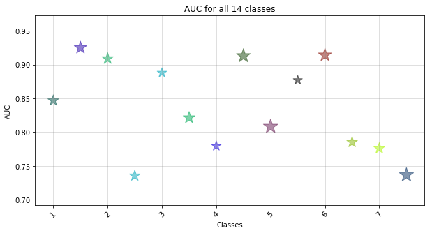

```
{'Effusion': 2, 'Pneumothorax': 7, 'Edema': 9, 'Cardiomegaly': 1, 'Pleural_Thickening': 12, 'Atelectasis': 0, 'Consolidation': 8, 'Emphysema': 10, 'Pneumonia': 6, 'Nodule': 5, 'Mass': 4, 'Infiltration': 3, 'Hernia': 13, 'Fibrosis': 11}
```

```python
print("evaluating on training data: ")
evaluate(trainingDF)
SQLContext(sc).clearCache()
```

## Evaluate the model based on the validation

```
evaluating on validation  data:
roc score for                Atelectasis  is:  0.780008270716
roc score for               Cardiomegaly  is:  0.861690840966
roc score for                   Effusion  is:  0.865470780768
roc score for               Infiltration  is:  0.678728872594
roc score for                       Mass  is:  0.81937252896
roc score for                     Nodule  is:  0.731773696509
roc score for                  Pneumonia  is:  0.685494899447
roc score for               Pneumothorax  is:  0.84966410216
roc score for              Consolidation  is:  0.760042028419
roc score for                      Edema  is:  0.848090533671
roc score for                  Emphysema  is:  0.881974314806
roc score for                   Fibrosis  is:  0.753294917453
roc score for         Pleural_Thickening  is:  0.740726466303
roc score for                     Hernia  is:  0.707347400953
('Finished evaluation, average auc: ', 0.7831199752660915)
plot of Area Under Curve for 14 classes
```

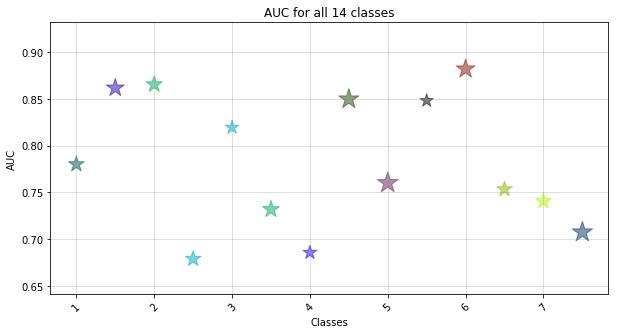

```
{'Effusion': 2, 'Pneumothorax': 7, 'Edema': 9, 'Cardiomegaly': 1, 'Pleural_Thickening': 12, 'Atelectasis': 0, 'Consolidation': 8, 'Emphysema': 10, 'Pneumonia': 6, 'Nodule': 5, 'Mass': 4, 'Infiltration': 3, 'Hernia': 13, 'Fibrosis': 11}
```

```python
print("\nevaluating on validation  data: ")
evaluate(validationDF)
```

## Loss function Graph

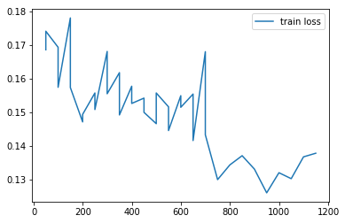

```python
import matplotlib as plt
import numpy as np

#pylab
%matplotlib notebook
%pylab inline
#import matplotlib.pyplot as plt
pylab.figure()

#retrieve train and validation summary object and read the loss data into ndarray's.
loss = np.array(train_summary.read_scalar("Loss"))

plt.plot(loss[:,0],loss[:,1],label='train loss')
#plt.plot(val_loss[:,0],val_loss[:,1],label='val loss') #,color='green')
#plt.scatter(val_loss[:,0],val_loss[:,1],color='green')
plt.legend();
```

```python
!tensorboard --logdir=/home/mahmood/ChestXray/logDirectory/logs/test_dell_x_ray/train --port 8082
```

[output not shown]

[output cut: 12 more lines]

[output not shown]